# Using Machine Learning to Predict Natural Gas Futures Prices

PSTAT 131 Term Project

Lewis Boslego

July 01, 2023

```r
library(tidymodels)
library(tidyverse)
library(magrittr)
library(scales)
library(MASS)
library(corrplot)
library(kknn)
library(discrim)
library(gridExtra)
library(ggpubr)
library(ggforce)
library(RColorBrewer)
library(kableExtra)

set.seed(1) # for reproducible results
```

## Introduction

In this project, I will attempt to predict, with the highest accuracy, the average monthly price of the Natural Gas Futures Contract 1 (NG1), traded on the New York Mercantile Exchange (NYMEX). This contract represents the agreement to take delivery of 10,000 million British thermal units (mmBtu) of natural gas three days before the last business day prior to the contract month.

This finalization of delivery accounts for less than 1% of trading volume, in energy markets, and the majority of the contracts are liquidated; as traders who purchased contracts will sell them back, and sellers will repurchase them, nullifying the need for physical delivery. Then why do most market participants purchase futures contracts with no intention of actually taking delivery? They trade these contracts in order to hedge or speculate. Companies that consume natural gas use the futures contracts to hedge against their final cost for the commodity. By purchasing futures contracts well before they need to utilize the natural gas, they are able to lock in prices, lowering their exposure to the future cost that they will incur. Traders who have no use for natural gas also engage in this market in order to speculate on the price of the contract. The motivation here is to generate positive returns from buying and selling contracts based on their beliefs about their future price, and to close out holdings before their contracts mature.

Within the market for natural gas futures, it is principal for participants to be able to accurately predict future prices. This leads me to the goal of this project: to see if with the proper variable selection and machine learning models, I can accurately predict natural gas futures prices.

The price for natural gas futures is highly volatile, however, meaning accurate prediction requires consideration of all variables that contribute to price changes. Luckily, the U.S. Energy Information Administration (EIA) has published many explanations of the natural gas market and all of its important variables. The EIA is a subset of the U.S. Department of Energy and is responsible for collecting and analyzing data on energy. According to the EIA, the main variables that contribute to natural gas price can be divided into supply and demand factors. The factors that make up the supply are production, storage levels, exports, and imports, and the demand factors are weather patterns, macroeconomic trends, and the price of substitutes.

The supply side of this market has a simple interpretation in that a notable increase or decrease in supply, without other simultaneous changes in the market, is likely to drive prices down or up, respectively. Production indicates future supply, storage is a measure of current supply, exports explains where some of production goes, along with being a measure of international demand, and imports measures by how much domestic production is supplemented. The demand is explained by weather patterns because natural gas is largely used in heating and cooling, and extreme weather, hot or cold, results in increased demand for natural gas. Macroeconomic trends determine demand, as economic growth correlates with increased need for energy, and economic contraction has the opposite effect. Lastly, natural gas is used as an energy source, and if other energy sources increase in price, natural gas will likely be utilized more and see more demand, and the opposite holds as well.

## Variable Selection

In order to capture these supply and demand factors that determine the price of natural gas, I have assembled a data set with the following composition:

Key:

- `date` - Month and year.
- `NG1` - NGC1 monthly average price (Dollars per mmBtu) (dependent variable).
- `NG1_lag1` - NGC1 monthly average price (Dollars per mmBtu), lagged one month.
- `rGDP_lag1` - U.S. monthly Real GDP Index ($Trillion), lagged one month.
- `CL1_lag1` - Cushing, OK Crude Oil Future Contract 1 (Dollars per barrel), monthly average, lagged one month.
- `storage_lag1` - U.S. natural gas monthly average storage (Bcf), lagged one month.
- `exports_lag1` - U.S. total monthly NG exports (Bcf), lagged one month.
- `imports_lag1` - U.S. total monthly NG imports (Bcf), lagged one month.
- `h_deg_day_lag_1` - U.S. total monthly weighted heating degree days, lagged one month.
- `h_deg_day_dev_norm_lag1` - U.S. total monthly weighted heating degree days minus normal monthly weighted heating degree days, lagged one month.
- `c_deg_day_lag1` - U.S. total monthly weighted cooling degree days, lagged one month.
- `c_deg_day_dev_norm_lag1` - U.S. total monthly weighted cooling degree days minus normal monthly weighted cooling degree days, lagged one month.
- `production_lag1` - U.S. monthly total dry natural gas production (Bcf), lagged one month.

To make a remark, only monthly values are used as the variables are end of month averages or cumulative monthly values. They are lagged by one month because the goal is to predict future prices using current / past information.

This data set has 310 sequential observations, spanning from February, 1997, to November, 2022, and a total of 13 variables.

Breaking down this data set, NG1 is the natural gas price and dependent variable, NG1_lag1 is the previous month’s price and will be predictive if any autocorrelation structure is present in the natural gas price, my guess is there is. rGDP is a variable meant to capture macroeconomic trends, and CL1 is a measure of the price for energy substitutes. Production, supply, imports, and exports are the supply variables as they were previously described. The degree day variables measure weather trends, and the degree day deviations are the difference between that month’s total degree days, and the data set average degree days for that given month, and they measure abnormal weather patterns.

## Exploratory Data Analysis

In order to better understand these variables, it is important to visualize their structure over time. This can also help to gauge their usefulness in this prediction setting, because variables that have deterministic structure are likely to be baked into natural gas price, and are not likely to explain price changes. Variables with more stochastic or random structures are inherently less predictable, and unexpected changes in them are more likely to be reflected by price changes.

The following plot, “Natural Gas Contract 1 Monthly Average Price,” shows the time series of the dependent variable. This variable has a minimum value of $1.70, and a maximum of $13.50. It usually ranges between $2 and $9, but has a few outliers. This process appears to be quite volatile, like previously assumed.

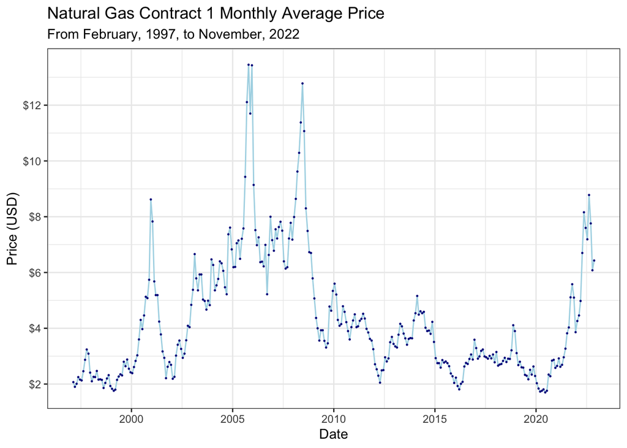

```r
ggplot(data = ng, aes(x = date)) +
  geom_line(aes(y = NG1), color = "lightblue") +
  geom_point(aes(y=NG1), size = .2, color = "darkblue") +
  scale_y_continuous(breaks =
                     round(seq(min(ng$NG1),
                     max(ng$NG1), by = 2)),
                     labels = scales::dollar_format()) +
  labs(title = "Natural Gas Contract 1 Monthly Average Price",
        subtitle = "From February, 1997, to November, 2022",
        x = "Date", y= "Price (USD)") +
  theme_bw()
```

The following plots, labelled “Supply Visualization,” show the structure of the production, storage, imports, and exports variables. Storage appears to be largely deterministic and is largely dominated by a seasonal pattern, and the remaining variables appear to have more stochastic structures, with simple time trends. Production appears to be slowly increasing, and imports and exports have inverse trends, where imports have decreased over time and exports have increased. Because of these variables structures, I predict that the stochastic variables will be more useful in predicting natural gas price than storage.

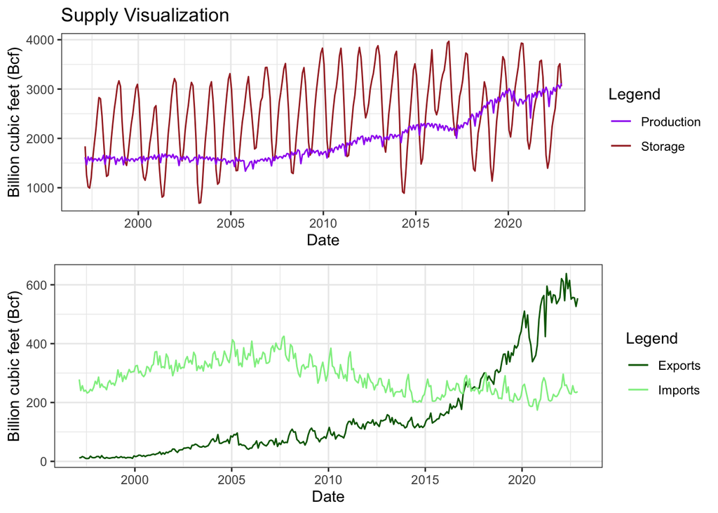

```r
colors <- c("Storage" = "brown",
            "Production" = "purple",
            "Exports" = "darkgreen",
            "Imports" = "lightgreen")

ps <- ggplot(data = ng, aes(x = date)) +
  geom_line(aes(y=storage_lag1, color = "Storage")) +
  geom_line(aes(y=production_lag1, color = "Production")) +
  labs(title = "Supply Visualization",
       x = "Date",
       y = "Billion cubic feet (Bcf)",
       color = "Legend") +
    scale_color_manual(values = colors) +
    theme(legend.key.size = unit(.8,"cm")) +
    theme_bw()

xm <- ggplot(data = ng, aes(x = date)) +
geom_line(aes(y=exports_lag1, color = "Exports")) +
geom_line(aes(y=imports_lag1, color = "Imports")) +
labs( x = "Date",
       y = "Billion cubic feet (Bcf)",
       color = "Legend") +
    scale_color_manual(values = colors) +
    theme(legend.key.size = unit(.8,"cm")) +
    theme_bw()

ggarrange(ps,xm, ncol = 1, nrow = 2)
```

The graphs below show that heating degree days and cooling degree days have a strong seasonal deterministic structure, and are likely to be baked into the price for natural gas, and should not explain much variation in it. More interestingly, the deviation from normal derivative variables have a more random structure, and are more likely to be reacted to by the dependent variable.

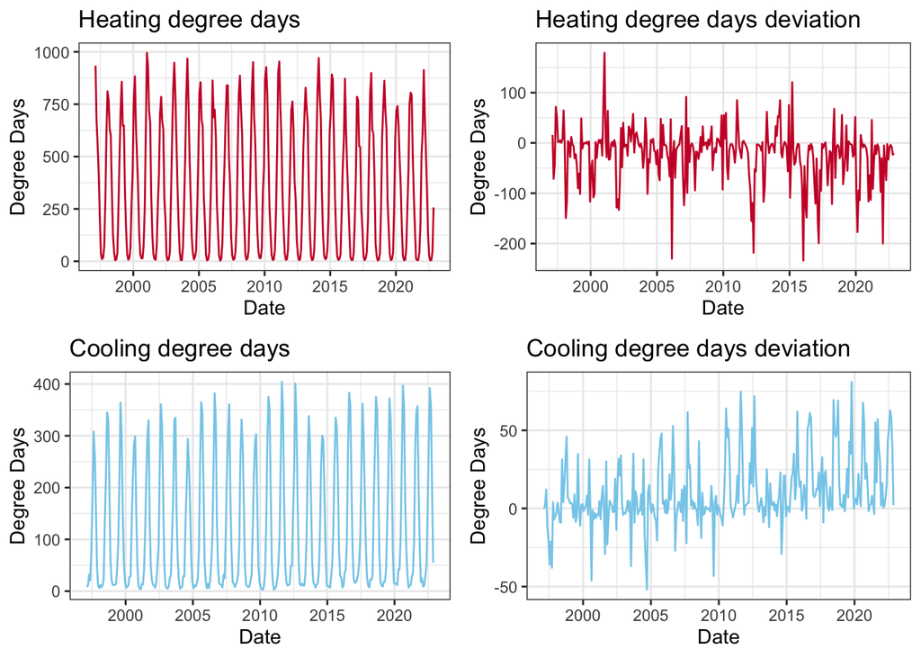

```r
a <- ggplot(data = ng, aes(x = date)) +
  geom_line(aes(y = h_deg_day_lag1), color = "#CC0033") +
  labs(title = "Heating degree days",
       x = "Date",
       y = "Degree Days") +
  theme_bw()
b <- ggplot(data = ng, aes(x = date)) +
  geom_line(aes(y = h_deg_day_dev_norm_lag1), color = "#CC0033") +
  labs(title = "Heating degree days deviation",
       x = "Date",
       y = "Degree Days") +
  theme_bw()
c <- ggplot(data = ng, aes(x = date)) +
  geom_line(aes(y = c_deg_day_lag1), color = "skyblue") +
  labs(title = "Cooling degree days",
       x = "Date",
       y = "Degree Days") +
  theme_bw()
d <- ggplot(data = ng, aes(x = date)) +
  geom_line(aes(y = c_deg_day_dev_norm_lag1), color = "skyblue") +
  labs(title = "Cooling degree days deviation",
       x = "Date",
       y = "Degree Days") +
  theme_bw()

ggarrange(a,b,c,d)
```

The two remaining variables that are not pictured are real GDP and Crude futures price, which have a slow linear trend structure and stochastic trend structure similar to NG1, respectively.

The variables of interest have the following correlation with each other. What’s most important is the correlation between NG1, the dependent variable, and all predictors. From this plot, NG1 has a very high correlation with its previous month’s value, a somewhat weak correlation with CL1, and a strong correlation with previous month’s imports. An interesting observation from this correlation plot is that NG1_lag1 has approximately the same correlation as NG1 with the other predictors. This suggests that not much information is lost by using the previous months data to make predictions. This is an important relationship to note however, because it may also suggest that the independent variables do not have as strong of a deterministic relationship with the dependent variable as previously thought.

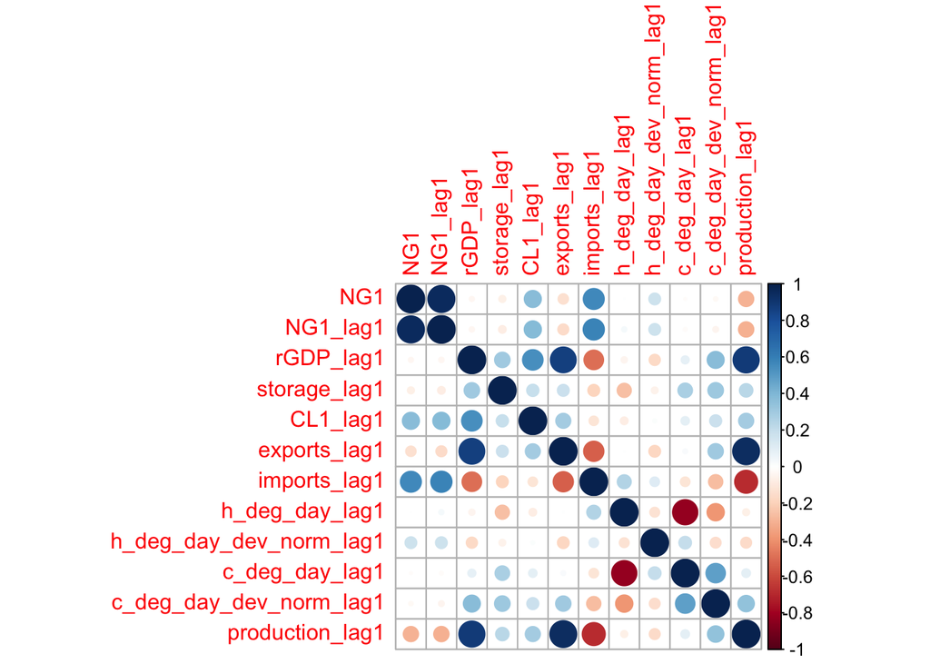

```r
ng %>%
  dplyr::select(-date) %>%
  cor() %>% corrplot()
```

## Data Split

In order to both calibrate and test machine learning models, it is necessary to first divide the data set into two components, a training data set and a testing data set. Each observation will be randomly assigned to one of these two groups, with the condition that 70% are allocated to the training set, and 30% to the testing set. The majority of observations are sent to training because a larger data sample is more likely to be representative of the true population, meaning models fit to the larger sample will better capture population structure. It also takes proportionally less data to test a model than it does to train it.

## Normalization

Normalization is a processing technique in which numerical variables are transformed to give them a similar range and scale. This technique is important in the context of this project because the variables range hugely in their scale and are measured in a variety of different units. These big differences among the data set are likely to have negative impacts on the accuracy and interpretability of machine learning models, and transforming the variables to have a similar range of values will improve their accuracy and interpretability. For these reasons, the data will be normalized.

## Cross-validation

Cross-validation describes a process where a training data set is divided into multiple smaller sets, and each of which are used interchangeably at different points both for training and testing. K-fold cross-validation is a take on this process, where the data are divided into k subsets, or folds, of equal size. Next, all but one of the k-folds are used to train the model, which is then tested on the remaining fold. The performance of the model trained and tested on this orientation of folds is then recorded, and this process is repeated so that every fold is used as the testing set. Finally, the recorded performance for each of these models is aggregated and averaged to represent the total performance of the machine learning model. This process leads to more accurate understanding of the performance of a model, which is much less likely to be overfit to particular structures.

Hyperparameters are model parameters that have a huge influence on how the model is applied and on its results, but it is rarely obvious what values are optimal for these hyperparameters. These values can be approximated, however, using k-folds cross-validation to carry out trial and error. To perform this, each potential hyperparameter value in a specified range is used to fit a model in the k-folds process, and the parameter value of the best performing model can be selected.

In this project, I will use k = 10 folds for model evaluation and hyperparameter tuning, for the motivations listed.

## Machine Learning Models:

For this project, the models that will be considered are linear regression, K-nearest neighbors, elastic net regression, and random forest. These different machine learning models each take unique approaches at forming predictions and minimizing estimation error. My attempting multiple approaches, there is a greater chance that one is a good fit for the data.

### Linear Regression

Linear regression is a method that attempts to capture the linear relationship between input variables and an output variable. This method is parametric and has the general form:

$$Y=\beta_0+\sum_{i=1}^{p}\beta_iX_i+\epsilon,$$

where Y is the dependent variable, Xi are the $i=1,..,p$ independent variables, variables, $\beta_0$ is a constant term, $\beta_i$ are the coefficients for the parameters, and $\epsilon$ is an error term equal to the additional variation in Y that is not observed in the input variables. Linear regression estimates the dependent variable with:

$$\hat{y}=\hat{\beta_0}+\sum_{i=1}^{p}\hat{\beta_i}X_i$$
and the goal is to minimize the sum of squared errors between the estimated value, y^, and the true value y,
$$\text{min }SSE = \sum(y_i-\hat{y_i})^2=
\sum(y_i-\hat{\beta_0}-\sum_{i=1}^{p}\hat{\beta_i}X_i)^2$$

This is done by finding minimizing weights for $\beta_{0-p}$ using the method of least squares. This model has no hyperparameters to tune, but benefits from cross validation because the data splitting technique allows for the accuracy of the linear model to be tested.

### K-Nearest Neighbors

KNN is a non-parametric machine learning algorithm that uses clustering to make predictions. This is a supervised learning model, meaning that this algorithm must first be calibrated with a training data set. This training data serves as a collection of example observations, where each example observation is a pair of a vector of inputs and an output value. With knowledge of how input vectors relate to output values, this algorithm can now take in a new input vector and by calculating the distance between the input vector and the training input vectors, it can approximate the new output, which equals the average of the outputs of the K closest training observations.

K is a hyperparameter that controls the sensitivity of the algorithm. It will be tuned using cross-validation, wherein the training data is split into subsets for training and validation, and a given value of K is trained on a training split and evaluated on the validation split, and this is done for a range of possible K values. The best performing K value will be selected for use.

### Elastic Net

Elastic-net regression combines two regularization techniques, LASSO and Ridge regression, in order to balance their shortcomings and aggregate their benefits. LASSO (least absolute shrinkage and selection operator) regression is a modified version of linear regression that minimizes the sum of squared errors by performing regularization. This regularization is carried out by penalizing variables that have little importance and would otherwise add noise to the model. This technique has the ability to perform variable selection by penalizing variables to the point that their weight equals zero. This model has the penalizing hyperparameter, $\lambda1$. Ridge regression is also a method of regularized regression, and performs this by addressing collinearity. By adding a penalty term to the parameters with high collinearity, this method is able to shrink their impact on the model, which would otherwise reduce its performance. The Ridge penalty term is a hyperparameter, $\lambda_2$, and generally, a higher value of $\lambda_2$ corresponds to a higher penalty on correlated variables.

Because elastic-net is a combination of these two approaches, it has both of their penalty terms, $\lambda_1$ & $\lambda_2$, and is therefore able to control both for collinearity and insignificant predictors. Both of these penalty terms are hyperparameters that should be tuned with cross-validation to improve their results.

### Random Forest

A random forest is an non-parametric ensemble learning algorithm that creates decision tree ‘forests’ and averages their outputs to make predictions. A forest is built with the following steps:

The algorithm first creates a bootstrapped data set from the training data, by taking a random sample with replacement. It then forms a decision tree with the bootstrapped data set, using a randomly sampled subset of variables to form each branch point. The algorithm then repeats these steps used to form many individual trees that aggregate to a random forest. Now, in order to form a prediction, the algorithm feeds a new test set of inputs into every decision tree in the forest, and averages the results.

Each tree is trained on many different combinations of the training data set, and different combinations of variables. This reduces overfitting to the training data and makes for robust results. This method is best suited for nonlinear data with many variables. This model has three hyperparameters that should be tuned, being the number of decision trees used, the number of variables that are subset, and the threshold of observation disagreement that cause trees to branch. These parameters should be tuned using cross validation in order to get the best results.

## Model Fitting and Selection Procedure

Now that important machine learning concepts have been established, and the models of interest have been defined, the model fitting procedure can be carried out. This procedure will have the following order:

1. Make initial 70/30 data split.
2. Set up the recipe and normalize predictors.
3. Create the 10 folds for k-fold cross-validation.
4. Set up machine learning models, and prepare their hyperparameters to be later tuned, if applicable.
5. Create model workflows by combining the models with the recipe.
6. Specify ranges for hyperparameters.
7. Find and choose optimal values for hyperparameters by tuning them over the specified ranges using cross-validation.
8. Compare how accurate each of these models are on the cross-validation data by calculating the RMSE for each.
9. Select the top performing models and fit them to the whole training data set.
10. Measure their accuracy, RMSE, on the testing set.
11. Conclude by selecting the model that is most accurate.

To elaborate on these steps where necessary, a recipe is a preprocessing step of model fitting where the dependent and independent variables are specified, the training data is supplied, and data transformations can be applied. Workflows are objects that allow a recipe allow a machine learning model to be added to a recipe. Optimal hyperparameters will be found using tuning grids, which calculate model accuracy for each possible hyperparameter. Models will be compared using RMSE, root mean squared error, which is a measure of prediction error. RMSE is a widely used metric for prediction accuracy in machine learning and has the useful characteristic that it is measured in the same units as the dependent variable, meaning its results are immediately interpretable.

1. Data split:

```r
# data split 70/30 training testing.
ng_split <- initial_split(ng, prop = 0.7, strata = NG1)
ng_train <- training(ng_split)
ng_test <- testing(ng_split)
```

2. Recipe formation:

```r
# Recipe creation.
ng_recipe <- recipe(NG1 ~ ., data = ng_train) %>%
             step_rm(date) %>%
             step_normalize(all_predictors())
# 'date' is removed because it is not a relavent predictor.
# Normalization is performed.
```

3. k-folds cross-validation with 10 folds:

```r
# k-folds creation, 10 folds are made.
ng_folds <- vfold_cv(ng_train, v=10, strata = NG1)
```

4. Model creation:

```r
# machine learning models specified for each method.
lm_model <- linear_reg(engine = "lm",
                       mode = "regression")
knn_model <- nearest_neighbor(neighbors = tune(),
                              mode = "regression",
                              engine = "kknn")
en_model <- linear_reg(penalty = tune(),
                       mixture = tune(),
                       engine = "glmnet",
                       mode = "regression")
rf_model <- rand_forest(mtry = tune(),
                        trees = tune(),
                        min_n = tune(),
                        mode = "regression") %>%
            set_engine("ranger", importance = "impurity")
```

5. Setting up model workflows:

```r
# model workflows
lm_workflow <- workflow() %>%
                add_model(lm_model) %>%
                add_recipe(ng_recipe)
knn_workflow <- workflow() %>%
                 add_model(knn_model) %>%
                 add_recipe(ng_recipe)
en_workflow <- workflow() %>%
                add_model(en_model) %>%
                add_recipe(ng_recipe)
rf_workflow <- workflow() %>%
                add_model(rf_model) %>%
                add_recipe(ng_recipe)
```

6. Hyperparameters are set up

```r
# hyperparameter specification
knn_grid <- grid_regular(neighbors(range = c(1,15)),
                         levels = 15)
en_grid <- grid_regular(penalty(range=c(0,1), trans = identity_trans()),
                        mixture(range=c(0,1)),
                                levels = 11)
rf_grid_2 <- grid_regular(mtry(range = c(1,7)),
                        trees(range = c(20,300)),
                        min_n(range(5,20)),
                        levels = 8)
```

In setting up the hyperparameters, the range for the KNN parameter, the number of nearest neighbors, is bound between 1 and 15, and each of these values will be considered. The optimal value of k is likely to be quite small, due to the high dimensionality of the data. The penalty and mixture of the elastic net are both specified to be within the range of 0 to 1 inclusive, and 11 levels between these bounds will be tested. The random forest hyperparameters, `mtry`, `trees`, and `min_n`, are equal the number of variables considered in each tree, the total number of trees in the forest, and the minimum amount of observations that cause a split, respectively. `mtry` has been set to range from 1 to 7 in order to limit the amount of trees that have `NG1_lag1` as a variable, which is important to prevent the forest from overfitting to this dominant variable. `trees` and `min_n` were given a reasonable range considering the computational cost they have.

7. Hyperparameter tuning:

```r
# hyperparameter tuning
knn_tune_grid <- tune_grid(knn_workflow,
                      resamples = ng_folds,
                      grid = knn_grid)
en_tune_grid <- tune_grid(en_workflow,
                     resamples = ng_folds,
                     grid = en_grid)
rf_tune_grid_2 <- tune_grid(rf_workflow,
                           resamples = ng_folds,
                           grid = rf_grid_2)

# saving computationally intensive tuning results
save(knn_tune_grid, file = "knn_tune_grid.rda")
save(en_tune_grid, file = "en_tune_grid.rda")
save(rf_tune_grid_2, file = "rf_tune_grid_2.rda")
```

```r
# loading tuning results
load("knn_tune_grid.rda")
load("en_tune_grid.rda")
load("rf_tune_grid_2.rda")
```

Visualizing the results of tuning:

This graph is of different values of the k-nearest neighbors parameter and shows that three neighbors is optimal in minimizing RMSE, which corresponds to an RMSE value of around 0.79.

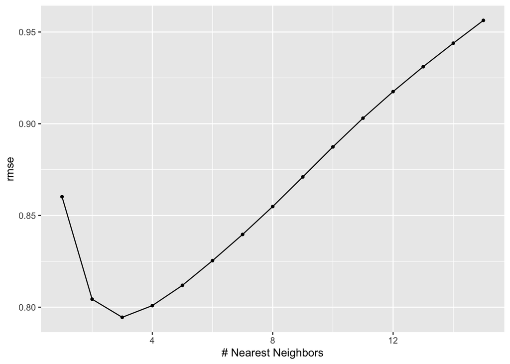

```r
autoplot(knn_tune_grid, metric = 'rmse')
```

This graph below shows different hyperparameter values of the elastic net perform with regards to RMSE, and it appears that a higher LASSO penalty and a lower amount of regularization work best to minimize RMSE.

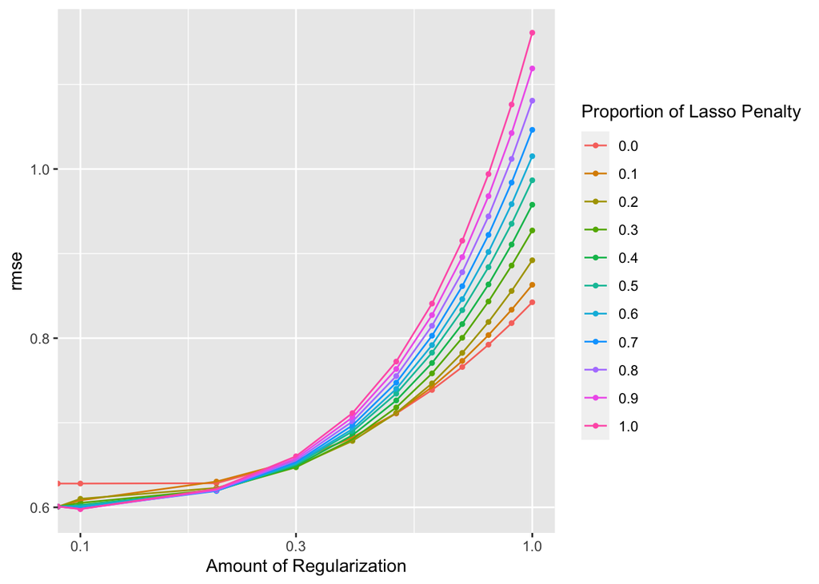

```r
autoplot(en_tune_grid, metric = 'rmse')
```

The following graphs show how well random forest perform with different amounts of variables, node sizes, and numbers of trees. From these plots, node size and the number of trees do not appear to have much of an impact on performance, but the optimal number of trees is greater than 50. The number of predictors is what has the largest impact on RMSE. I believe this is the result of `NG1_lag1` being such a dominant predictor, and this random forest performs better when it is more likely to split on this variable.

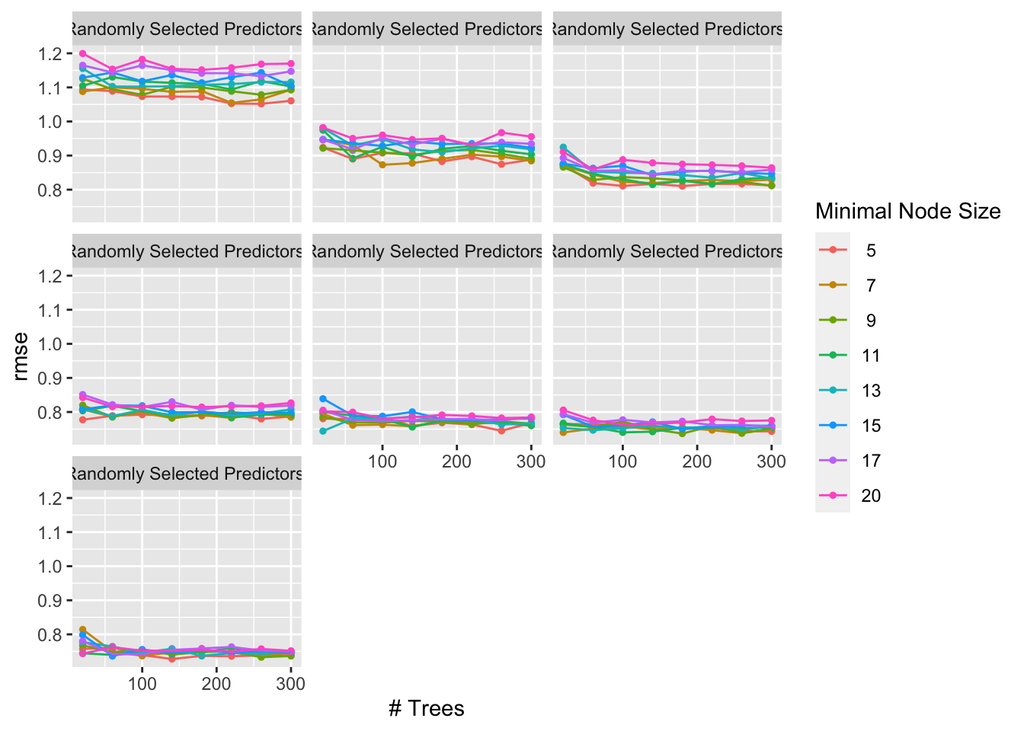

```r
autoplot(rf_tune_grid_2, metric = "rmse")
```

8. RMSE for each model:

Linear regression and elastic net performed much better in cross validation than KNN and random forest. The RMSE for each of these models are in the table below. Because linear regression and elastic net models had an difference in RMSE 0.004, I will proceed with both of these models, and conclude the consideration of KNN and random forest.

```r
# Calculating lowest RMSE for each model

lm_fit <- fit_resamples(lm_workflow, resamples = ng_folds)

lm_rmse <- collect_metrics(lm_fit, metric = 'rmse') %>%
           filter(.metric == "rmse") %>%
           dplyr::select(mean) %>% as.numeric()
knn_lowest_rmse <- show_best(knn_tune_grid, metric = 'rmse', n = 1) %>%
            dplyr::select(mean) %>% as.numeric()
en_lowest_rmse <- show_best(en_tune_grid, metric = 'rmse', n = 1) %>%
           dplyr::select(mean) %>% as.numeric()
rf_lowest_rmse <- show_best(rf_tune_grid_2, metric = 'rmse', n = 1) %>%
           dplyr::select(mean) %>% as.numeric()

cv_rmse <- as_tibble(c("Linear regression", "K-nearest neighbors",
                   "Elastic net", "Random forest")) %>%
          mutate(RMSE = c(lm_rmse, knn_lowest_rmse,
                   en_lowest_rmse, rf_lowest_rmse)) %>%
          rename("Model"="value")

kable(cv_rmse, caption = "Model cross-validation RMSE")
```

Model cross-validation RMSE

| Model | RMSE |
| --- | --- |
| Linear regression | 0.6022721 |
| K-nearest neighbors | 0.7944879 |
| Elastic net | 0.5979035 |
| Random forest | 0.7276491 |

9. Fitting the remaining models, linear regression and elastic net, to the whole training set:

```r
best_en <- select_best(en_tune_grid, metric = "rmse")
en_final_workflow <- finalize_workflow(en_workflow, best_en)


lm_fit_train <- fit(lm_workflow, data = ng_train)
en_fit_train <- fit(en_final_workflow, data = ng_train)
```

10. Fitting the models to the testing data and computing their testing RMSE:

```r
lm_predict_test <- predict(lm_fit_train, new_data = ng_test[,-2]) %>%
  mutate(NG1 = ng_test$NG1)

en_predict_test <- predict(en_fit_train, new_data = ng_test[,-2]) %>%
  mutate(NG1 = ng_test$NG1)

ng_metric <- metric_set(rmse)

lm_test_rmse <- ng_metric(lm_predict_test, truth = NG1, estimate = .pred) %>%
  dplyr::select(.estimate) %>% as.numeric()
en_test_rmse <- ng_metric(en_predict_test, truth = NG1, estimate = .pred) %>%
    dplyr::select(.estimate) %>% as.numeric()

test_rmse <- as_tibble(c("Linear regression", "Elastic net")) %>%
          mutate(RMSE = c(lm_test_rmse, en_test_rmse)) %>%
  rename("Model" = "value")

kable(test_rmse, caption = "Model test RMSE")
```

Model test RMSE

| Model | RMSE |
| --- | --- |
| Linear regression | 0.7795254 |
| Elastic net | 0.8164909 |

11. Select the model that is most accurate:

Because the linear regression model had a lower testing RMSE of 0.7795254, compared to the elastic net’s 0.8164909, I will select the linear regression model as the best model for this question. This model has the form:

$$\hat{y}= 4.236 + 1.895*x_1 + 0.005*x_2 + 0.030*x_3 + 0.058*x_4 \\
+ 0.347*x_5 + 0.081*x_6 - 0.0163*x_7 + 0.082*x_8 \\
- 0.143*x_9 + 0.058*x_{10} - 0.343*x_{11},$$
for the variables $x_1:x_{11}$ equal to `NG1_lag1`, `rGDP_lag1`, `CL1_lag1`, `storage_lag1`, `exports_lag1`, `imports_lag1`, `h_deg_day_lag_1`, `h_deg_day_dev_norm_lag1`, `c_deg_day_lag1`, `c_deg_day_dev_norm_lag1`, and `production_lag1`, respectively.

The following plot, “Linear regression prediction accuracy for NG1,” shows how linear regression predictions, the red triangles, compare the the true prices of NG1, the black circles. From this plot, it is clear that the linear model is relatively accurate at predicting the structure, but falls short in predicting large price changes.

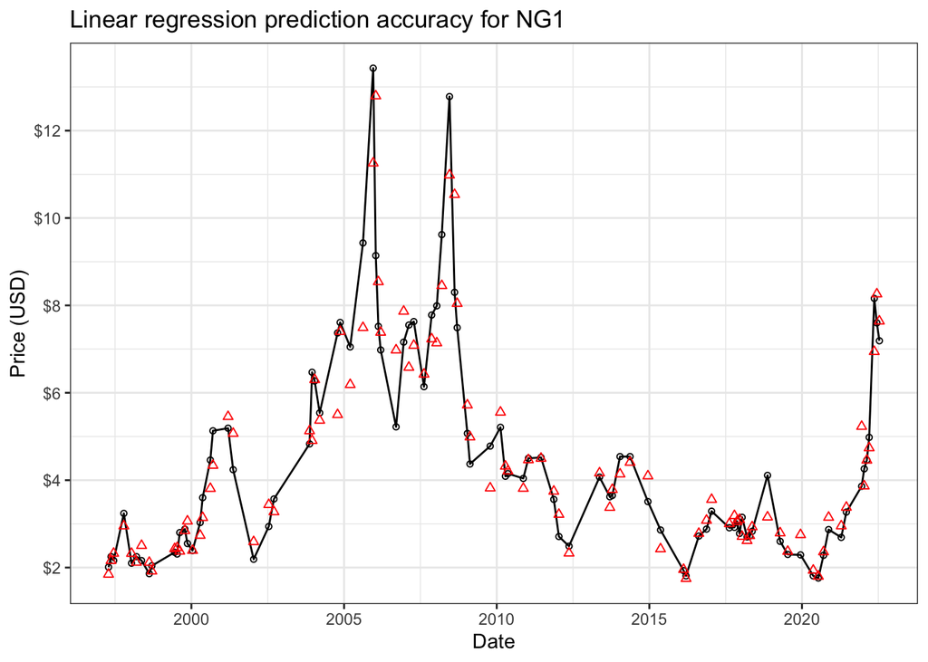

```r
lm_predict_test %>% mutate(date = ng_test$date) %>%
ggplot( aes(x = date)) +
  geom_line(aes(y =NG1), col = "black") +
  geom_point(aes(y= NG1), shape =1, col = "black", size =1.2) +
    geom_point(aes(y=.pred), color = "red", shape = 24, size = 1.5) +
  scale_y_continuous(breaks =
                     round(seq(min(ng_test$NG1),
                     max(ng_test$NG1), by = 2)),
                     labels = scales::dollar_format()) +
  labs(
    title = "Linear regression prediction accuracy for NG1",
    x = "Date", y="Price (USD)") +
  theme_bw()
```

## Conclusion

In this project, I set out to predict with the highest accuracy, the monthly average price for the one month natural gas futures contract. I pursued this goal by collecting predictive variables, and fitting machine learning models. My findings were that the variables equal to previous month’s average price for the natural gas contract, the previous month’s average price for the crude oil contract, the previous month’s total natural gas imports, and the previous month’s total natural gas production had the greatest correlation with the price of this natural gas futures contract. I also found that linear regression was the best model to predict this price, as it had the lowest prediction error, RMSE, of the machine learning models fit. This linear regression model had an RMSE of 0.7795254 on the testing data. This RMSE means that the predictions of this model vary on average by $0.78. The average price for NG1 is around $4.30, meaning that an regression estimate of this price should be inaccurate by about 18%, roughly speaking.

From the perspective of a speculative trader trying the maximize their return on high frequency trades, a monthly projection or estimate such as this does not have much immediate use for such trades, but it is of great importance to have a hypothesis or prediction about where the market is headed in order act logically with consideration for the bigger picture. It could also be useful to a natural gas company or other business that utilizes natural gas, in order to better understand what they can expect from the future in profits or operational costs.

Linear regression being the best model is generally a good result because this method is the simplest and easiest to interpret of the machine learning methods evaluated in this project. It is a somewhat disappointing result, however, because it had relatively inaccurate results and one would hope that far more sophisticated and computationally intensive machine learning techniques could produce more accurate results.

## Sources

All of the data, except for the monthly real GDP estimates, came from the U.S. Energy Information Administration (EIA), as well as the main guide used for variable selection. Many of the facts and information about the natural gas futures market came from the EIA as well. [Source](https://www.eia.gov/)

The data for real GDP estimates was sourced from S&P Global, who publish a monthly US GDP Index. [Source](https://www.spglobal.com/marketintelligence/en/mi/products/us-monthly-gdp-index.html)

Facts and information about the dynamics of the futures market came from [“A Guide to Energy Hedging.”](http://www.kisfutures.com/GuideEnergyHedging_NYMEX.pdf)

Descriptions of machine learning models were in part sourced from [“An Introduction to Statistical Learning: with applications in R.”](https://www.statlearning.com/)